# The Linear Model

## The linear equation

\[ y_i = \beta_0 + \beta_1x \] \(\beta_0\) = intercept \(\beta_1\) = slope

You might recognize this simple equation from as far back as high school. This equation describes a straight line, but is also the backbone of the linear model - the deterministic part.

## The stochastic part

Of course, real data are variable, so we need some way of capturing the way in which our results vary relative to the expectation. We do this in a linear model by adding an error component.

\[ \begin{gather} y_i = \beta_0 + \beta_1x_i + \epsilon_i\\ \epsilon_i \sim \text{Normal}(0, \sigma) \end{gather} \]

## Another formulation

Another way of mathematically writing out the linear model is as follows:

\[ \begin{gather} y_i \sim \text{Normal}(\mu, \sigma)\\ \mu = \beta_0 + \beta_1x \end{gather} \]

## Regression

Linear regression is the easiest to relate to the linear model format.

It breaks down to:

\[ \begin{gather} y_i\sim \text{Normal}(\mu, \sigma)\\ \mu = \beta_0 + \beta_1x\\ H_0 : \beta_1 = 0 \end{gather} \]

## Example

For example let’s consider the Wizard intertidal dataset. For now, I’ve removed rows with NA values and then calculated species richness for each remaining quadrat.

Let’s plot richness at each quadrat against year. To make some things easier, year has been converted to values ranging from 0 to 21, with 0 being 2001 and 21 being 2022

```r
wizardplot <-
  ggplot(wizard2) +
  geom_jitter(aes(y = richness,
                  x = year),
              width = 0.3,
              height = 0,
              alpha = 0.5) +
  labs(x = "Year",
       y = "Species Richness")
```

## View the plot

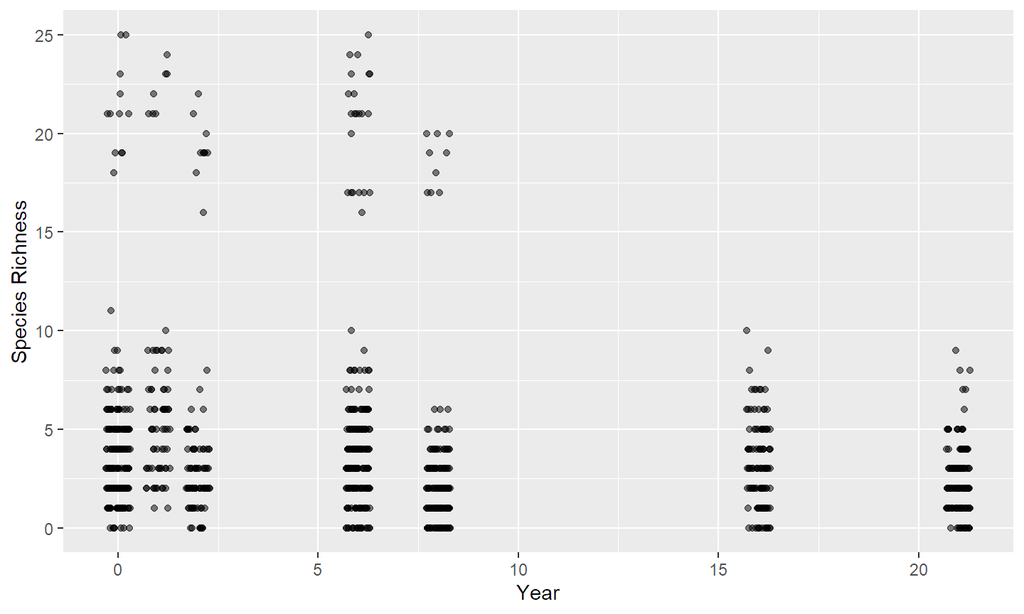

```r
wizardplot
```

## Fit a regression

Let’s start off with a linear regression and see how the result relates to our linear equation.

There are many reasons why this is the wrong model for our data. Can you think of some?

```r
wizard.regression <-
  lm(richness ~ year,
     data = wizard2)
```

## View the output

```r
summary(wizard.regression)
```

```
##
## Call:
## lm(formula = richness ~ year, data = wizard2)
##
## Residuals:
##     Min      1Q  Median      3Q     Max
## -4.9651 -2.7180 -0.9766  0.7762 20.7762
##
## Coefficients:
##             Estimate Std. Error t value Pr(>|t|)
## (Intercept)  4.96514    0.20386  24.355  < 2e-16 ***
## year        -0.12356    0.01958  -6.311  4.1e-10 ***
## ---
## Signif. codes:  0 '***' 0.001 '**' 0.01 '*' 0.05 '.' 0.1 ' ' 1
##
## Residual standard error: 4.481 on 1032 degrees of freedom
## Multiple R-squared:  0.03716,    Adjusted R-squared:  0.03623
## F-statistic: 39.83 on 1 and 1032 DF,  p-value: 4.103e-10
```

## \(R^2\)

AKA the coefficient of determination.

“The proportion of the variation in the dependent variable that is predictable from the independent variable(s).”

\[ \begin{gather} R^2 = 1 - \frac{SS_{res}}{SS_{tot}}\\ R^2 = 1 - \frac{\sum_i(y_i - \hat{y})^2}{\sum_i(y_i - \bar{y})^2}\\ \end{gather} \] \(\hat{y}\) = fitted response \(\bar{y}\) = mean response

```r
intercept <- wizard.regression$coefficients["(Intercept)"]
slope <- wizard.regression$coefficients["year"]
fitted <- intercept + slope * wizard2$year
SSres <- sum((wizard2$richness - fitted)^2)
SStot <- sum((wizard2$richness - mean(wizard2$richness))^2)
R2 <- 1 - SSres/SStot
R2
```

```
## [1] 0.0371622
```

## Adjusted \(R^2\)

\[ \begin{gather} \bar{R^2} = 1 - \frac{SS_{res}/df_{res}}{SS_{tot}/df_{tot}} \\ df_{res} = n - p \\ df_{tot} = n-1 \\\\ \bar{R^2} = 1 - (1 - R^2)\frac{n - 1}{n - p} \end{gather} \]

```r
n <- length(wizard2)
p <- 1
aR2 <- 1 - ((1-R2) * (n - 1) / (n - p))
aR2
```

[output not shown]

## Plot based on the LM equation

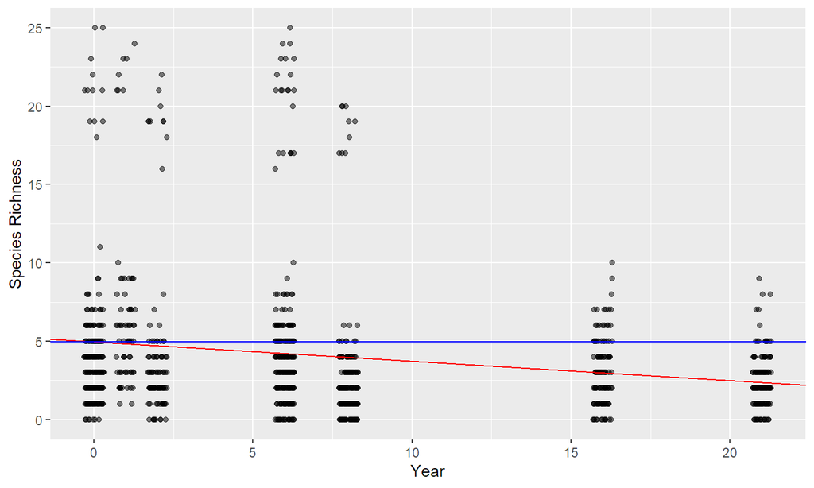

```r
wizardplot +
  geom_abline(aes(slope = slope, intercept = intercept), colour = "red") +
  geom_abline(aes(intercept = intercept, slope = 0), colour = "blue")
```

## Residual standard error

```r
summary(wizard.regression)
```

```
##
## Call:
## lm(formula = richness ~ year, data = wizard2)
##
## Residuals:
##     Min      1Q  Median      3Q     Max
## -4.9651 -2.7180 -0.9766  0.7762 20.7762
##
## Coefficients:
##             Estimate Std. Error t value Pr(>|t|)
## (Intercept)  4.96514    0.20386  24.355  < 2e-16 ***
## year        -0.12356    0.01958  -6.311  4.1e-10 ***
## ---
## Signif. codes:  0 '***' 0.001 '**' 0.01 '*' 0.05 '.' 0.1 ' ' 1
##
## Residual standard error: 4.481 on 1032 degrees of freedom
## Multiple R-squared:  0.03716,    Adjusted R-squared:  0.03623
## F-statistic: 39.83 on 1 and 1032 DF,  p-value: 4.103e-10
```

```r
rse <- summary(wizard.regression)$sigma
```

In the lm output, RSE is an estimate of \(\sigma\) in our linear model formulation.

## Putting the pieces together

We can simulate new data based the parameter estimates from our LM.

```r
newwizard <-
  data.frame(year = wizard2$year)

newwizard$mean <-
  with(newwizard,
       intercept + slope * year)

newwizard$richness <-
  with(newwizard,
       rnorm(n = nrow(newwizard),
             mean = mean,
             sd = rse))
```

## Plot our new data

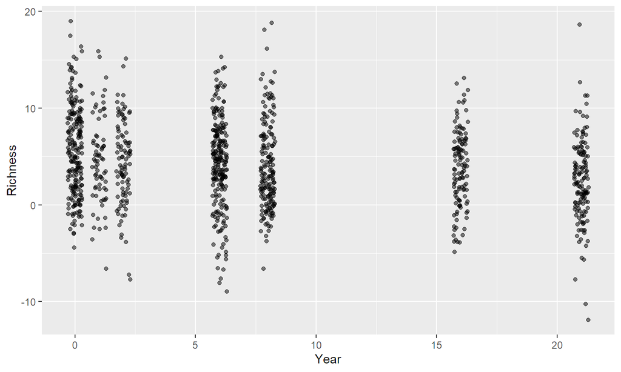

```r
newwizardplot <-
  ggplot(newwizard) +
  geom_jitter(aes(y = richness, x = year), width = 0.3, height = 0,
              alpha = 0.5) +
  labs(x = "Year", y = "Richness")
newwizardplot
```

## Thinking about assumptions

Plotting our original data against our simulated data, it’s clear we need to think deeper about our model assumptions!

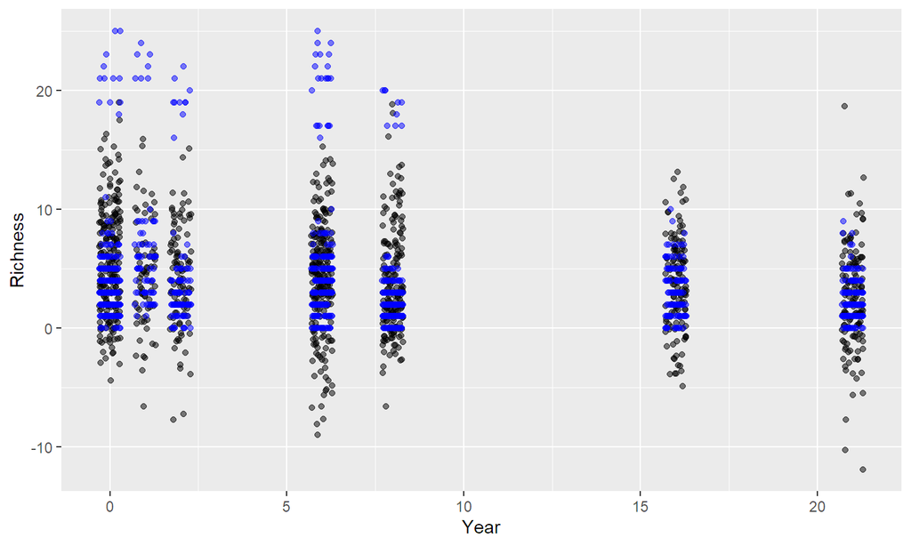

```r
newwizardplot +
  geom_jitter(data = wizard2, aes(y = richness, x = year), width = 0.3,
              height = 0, alpha = 0.5, colour = "blue")
```

## LM assumptions

The main assumptions of an LM are

1. Independence
2. Response variable is distributed over predictors in a way similar to the assumed distribution.

For a normal distribution this would look like:

1. Normally distributed residuals
2. Equal variance in residuals

Which of these assumptions are our data not matching?

## Model validation

A common approach to checking model fit is using a residuals vs. fitted plot.

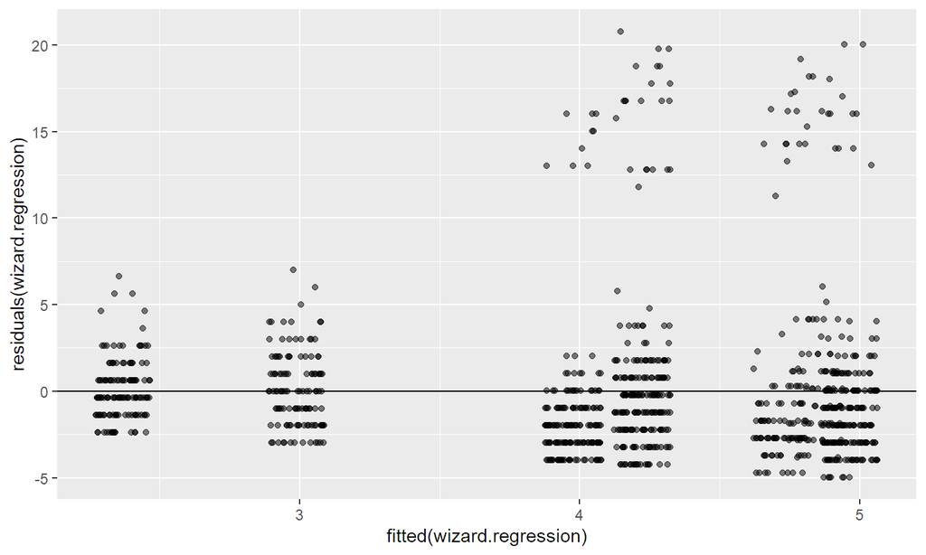

```r
ggplot() +
  geom_jitter(aes(x = fitted(wizard.regression),
                  y = residuals(wizard.regression)), width = 0.1, height = 0,
              alpha = 0.5) + geom_hline(aes(yintercept = 0))
```

## One-sample t-test

We can think of this as a special case of the LM equation from before, with just the intercept part.

\[ \begin{gather} y_i \sim \text{Normal}(\mu, \sigma)\\ \mu = \beta_0\\ H_0 : \beta_0 = 0 \end{gather} \]

## Example

Consider the Wizard richness data from just 2022. What would a one-sample t-test do here? How about two-sided vs. one-sided?

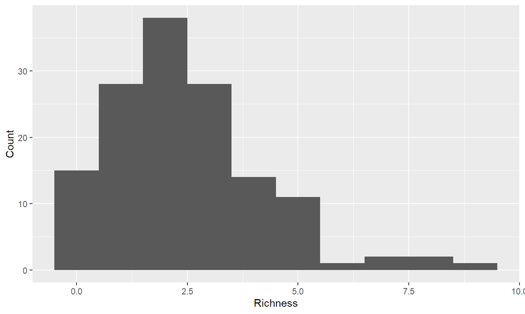

```r
wizard2022 <- wizard2 %>% filter(year == 21)
richness2022plot <- ggplot(wizard2022) +
  geom_histogram(aes(x = richness), binwidth = 1) + labs(x = "Richness", y = "Count")
richness2022plot
```

## Run a one-sample t-test

Let’s say we have past data suggesting that overall average species richness at our sites was 2 and we want to test wether richness was greater in 2022.

```r
richness2022.t.test <- t.test(wizard2022$richness, mu = 2,
                              alternative = "greater")
richness2022.t.test
```

```
##
##  One Sample t-test
##
## data:  wizard2022$richness
## t = 3.0798, df = 139, p-value = 0.001248
## alternative hypothesis: true mean is greater than 2
## 95 percent confidence interval:
##  2.211356      Inf
## sample estimates:
## mean of x
##  2.457143
```

## Extract parameter estimates

```r
meanrichness2022 <- richness2022.t.test$estimate
meanrichness2022
```

```
## mean of x
##  2.457143
```

```r
serichness2022 <- richness2022.t.test$stderr
serichness2022
```

```
## [1] 0.1484318
```

## Plot

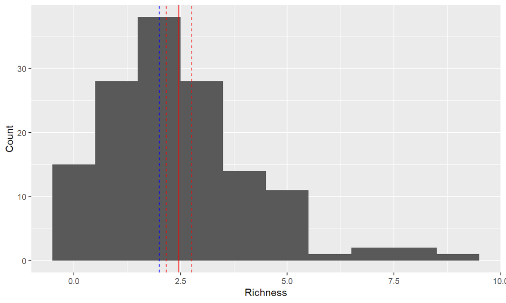

```r
richness2022plot +
  geom_vline(aes(xintercept = meanrichness2022), colour = "red") +
  geom_vline(aes(xintercept = meanrichness2022 + 1.96 * serichness2022),
             colour = "red",
             linetype = "dashed") +
  geom_vline(aes(xintercept = meanrichness2022 - 1.96 * serichness2022),
             colour = "red",
             linetype = "dashed") +
  geom_vline(aes(xintercept = 2),
             colour = "blue",
             linetype = "dashed")
```

## Two-sample t-test

We can extend the one-sample t-test to a two-sample test by adding \(\beta_1\) and \(x\) back into our linear equation.

\[ \begin{gather} y_i\sim \text{Normal}(\mu, \sigma)\\ \mu = \beta_0 + \beta_1x\\ H_0 : \beta_1 = 0 \end{gather} \]

This is the same as our regression equation!

Except now \(x\) works as a binary variable that gets turned off whether the data comes from group 1 (0) or group 2 (1). \(\beta_0\) is the mean of group 1 and \(\beta_1\) is the difference between groups 1 and 2.

For example, if \(\beta_0 = 5\) and \(\beta_1 = -4\), what are the means of groups 1 and 2?

## Run a two-sample t-test

We can compare species richness between our exposed and sheltered sites in 2022.

```r
richness2022.2sample.t.test <- t.test(richness ~ exposure, data = wizard2022)
richness2022.2sample.t.test
```

```
##
##  Welch Two Sample t-test
##
## data:  richness by exposure
## t = 6.8781, df = 110.68, p-value = 3.794e-10
## alternative hypothesis: true difference in means between group exposed and group sheltered is not equal to 0
## 95 percent confidence interval:
##  1.252026 2.265426
## sample estimates:
##   mean in group exposed mean in group sheltered
##                3.323944                1.565217
```

## Compare with lm

```r
richness2022.2sample.t.test.lm <- lm(richness ~ exposure, data = wizard2022)
summary(richness2022.2sample.t.test.lm)
```

```
##
## Call:
## lm(formula = richness ~ exposure, data = wizard2022)
##
## Residuals:
##     Min      1Q  Median      3Q     Max
## -3.3239 -0.5652 -0.3239  0.6761  5.6761
##
## Coefficients:
##                   Estimate Std. Error t value Pr(>|t|)
## (Intercept)         3.3239     0.1809  18.378  < 2e-16 ***
## exposuresheltered  -1.7587     0.2576  -6.827 2.53e-10 ***
## ---
## Signif. codes:  0 '***' 0.001 '**' 0.01 '*' 0.05 '.' 0.1 ' ' 1
##
## Residual standard error: 1.524 on 138 degrees of freedom
## Multiple R-squared:  0.2525, Adjusted R-squared:  0.247
## F-statistic:  46.6 on 1 and 138 DF,  p-value: 2.526e-10
```

## Extract the parameter estimates

```r
meanrichness2022.e <- richness2022.2sample.t.test$estimate[1]
meanrichness2022.s <- richness2022.2sample.t.test$estimate[2]
meanrichness2022.e
```

```
## mean in group exposed
##              3.323944
```

```r
meanrichness2022.s
```

```
## mean in group sheltered
##                1.565217
```

```r
serichness2022.es <- richness2022.2sample.t.test$stderr
serichness2022
```

```
## [1] 0.1484318
```

## Plot everything

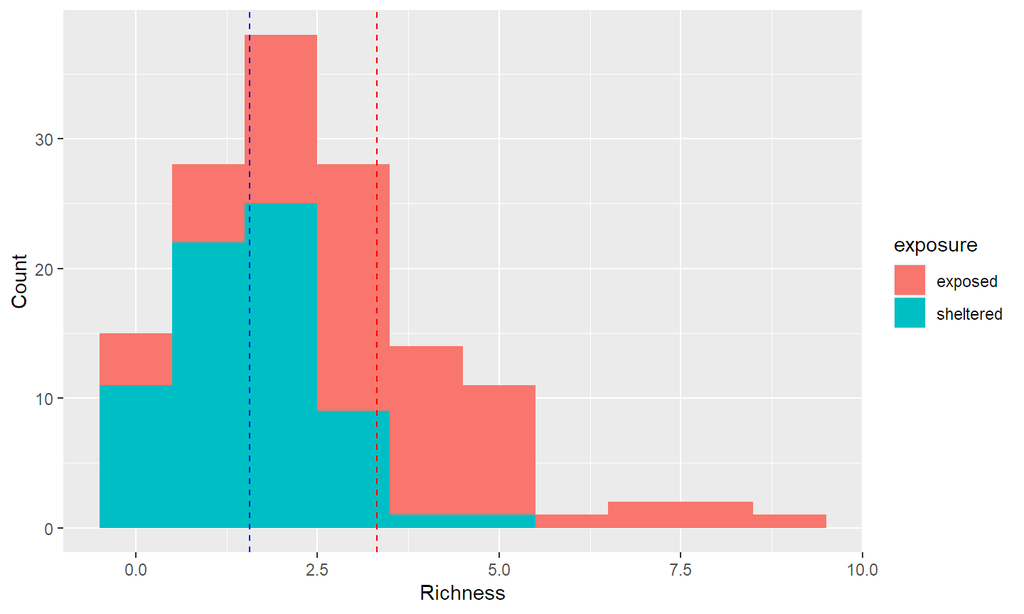

```r
ggplot(wizard2022) +
  geom_histogram(aes(x = richness, fill = exposure), binwidth = 1) +
  labs(x = "Richness", y = "Count") +
  geom_vline(aes(xintercept = meanrichness2022.e), colour = "red",
             linetype = "dashed") +
  geom_vline(aes(xintercept = meanrichness2022.s), colour = "blue",
             linetype = "dashed")
```

## One-way ANOVA

What if we want to compare across a categorical variable with more than two groups?

We can do this with a one-way ANOVA.

\[ \begin{gather} y_i\sim \text{Normal}(\mu, \sigma)\\ \mu = \beta_0 + \beta_1x_1 + \beta_2x_2\ +\ ...\\\\ H_0 : \beta_1 = 0,\ \beta_2 = 0 \end{gather} \] Where \(x_j\) is an indicator (0 or 1) which turns on or off \(\beta_j\).

## Example

Consider the Wizard data again, but this time we’ll compare data from 2009, 2017, and 2022, using year as a categorical variable.

```r
wizard07to22 <- wizard2 %>% filter(year >= 8)
wizard07to22$year <- as.factor(wizard07to22$year)
wizard07to22.ANOVA <- aov(richness ~ year, data = wizard07to22)
summary(wizard07to22.ANOVA)
```

```
##              Df Sum Sq Mean Sq F value Pr(>F)
## year          2     25  12.668   1.453  0.235
## Residuals   431   3757   8.716
```

```r
beta.0 <- wizard07to22.ANOVA$coefficients[1]
beta.1 <- wizard07to22.ANOVA$coefficients[2]
beta.2 <- wizard07to22.ANOVA$coefficients[3]
```

## Compare with lm

```r
wizard07to22.ANOVA2 <- lm(richness ~ year, data = wizard07to22)
summary(wizard07to22.ANOVA2)
```

```
##
## Call:
## lm(formula = richness ~ year, data = wizard07to22)
##
## Residuals:
##     Min      1Q  Median      3Q     Max
## -3.0833 -1.7471 -0.4571  0.9167 17.2529
##
## Coefficients:
##             Estimate Std. Error t value Pr(>|t|)
## (Intercept)   2.7471     0.2238  12.274   <2e-16 ***
## year16        0.3362     0.3503   0.960    0.338
## year21       -0.2900     0.3352  -0.865    0.387
## ---
## Signif. codes:  0 '***' 0.001 '**' 0.01 '*' 0.05 '.' 0.1 ' ' 1
##
## Residual standard error: 2.952 on 431 degrees of freedom
## Multiple R-squared:  0.006699,   Adjusted R-squared:  0.00209
## F-statistic: 1.453 on 2 and 431 DF,  p-value: 0.2349
```

## Plot

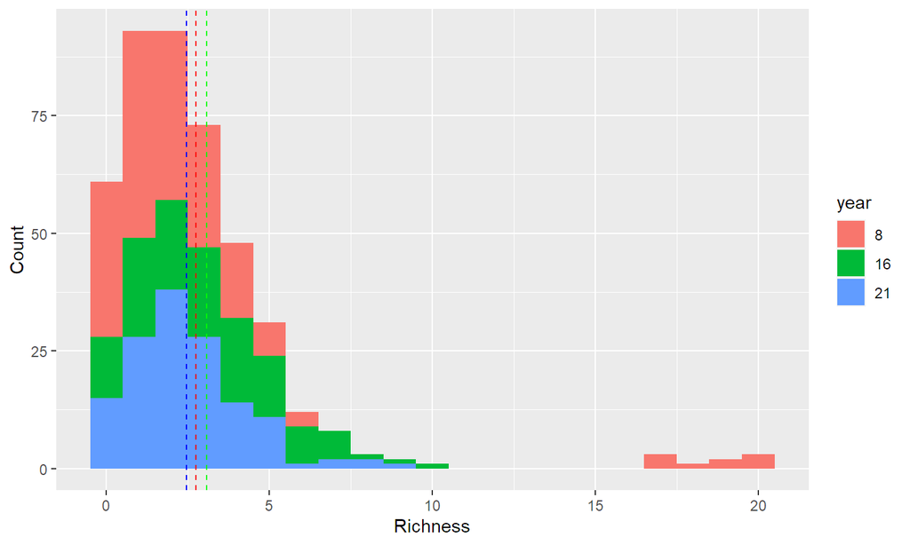

```r
ggplot(wizard07to22) +
  geom_histogram(aes(x = richness, fill = year), binwidth = 1) +
  labs(x = "Richness", y = "Count") +
  geom_vline(aes(xintercept = beta.0), colour = "red",
             linetype = "dashed") +
  geom_vline(aes(xintercept = beta.0 + beta.1), colour = "green",
             linetype = "dashed") +
  geom_vline(aes(xintercept = beta.0 + beta.2), colour = "blue",
             linetype = "dashed")
```

## Two-way ANOVA

The linear equation for the two-way ANOVA is a like having an interaction in an ANCOVA, but now the interaction is between two categorical variables.

\[ \mu = \beta_0 + \beta_1X_1 + \beta_2X_1 + \beta_3X_1X_2 \]

\(\beta_j\) are vectors \(\beta\) which are turned on or off by indicator vector \(X_j\).

## Example

Say we want to compare across exposed/unexposed sites as well as across the all the study years as a categorical variable.

If the exposed site in 2001 is our reference group, some year and group combination means would look like:

## Fit the model

We’ll exclude 2002, 2003, and 2017 because there aren’t sheltered site data.

```r
wizard3 <- wizard2 %>% filter(year != 1 & year != 2 & year != 16)
wizard3$year <- as.factor(wizard3$year)
wizard.ANOVA <- lm(richness ~ year * exposure, data = wizard3)
```

## View output

```r
summary(wizard.ANOVA)
```

```
##
## Call:
## lm(formula = richness ~ year * exposure, data = wizard3)
##
## Residuals:
##     Min      1Q  Median      3Q     Max
## -6.0667 -2.3025 -0.9048  0.6761 19.6952
##
## Coefficients:
##                          Estimate Std. Error t value Pr(>|t|)
## (Intercept)               5.30476    0.42312  12.537  < 2e-16 ***
## year6                     0.76190    0.59838   1.273 0.203322
## year8                    -3.40000    0.63468  -5.357 1.13e-07 ***
## year21                   -1.98082    0.66618  -2.973 0.003041 **
## exposuresheltered        -1.68571    0.59838  -2.817 0.004975 **
## year6:exposuresheltered  -0.07843    0.83371  -0.094 0.925075
## year8:exposuresheltered   3.31429    0.88923   3.727 0.000208 ***
## year21:exposuresheltered -0.07301    0.94619  -0.077 0.938514
## ---
## Signif. codes:  0 '***' 0.001 '**' 0.01 '*' 0.05 '.' 0.1 ' ' 1
##
## Residual standard error: 4.336 on 740 degrees of freedom
## Multiple R-squared:  0.0958, Adjusted R-squared:  0.08724
## F-statistic:  11.2 on 7 and 740 DF,  p-value: 1.599e-13
```

## Interpret

There are eight different beta values here, so it’s a bit painful to extract them all and plot them separately. As a shortcut, we can make a dummy dataset and extract fitted values from the model.

```r
dummydata <- expand.grid(year = factor(levels(wizard3$year)),
                         exposure = levels(wizard3$exposure))

dummypredict <- predict(wizard.ANOVA, newdata = dummydata, se.fit = TRUE)

dummydata$fitted <- dummypredict$fit
dummydata$lower95 <- with(dummypredict, fit - 1.96 * se.fit)
dummydata$upper95 <- with(dummypredict, fit + 1.96 * se.fit)
```

## Plot

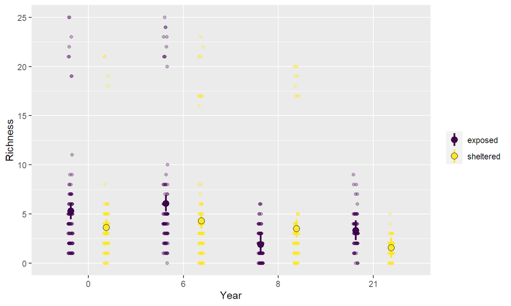

```r
ggplot(wizard3, out.width='50%', fig.align='center') +
  geom_jitter(aes(x = year, y = richness, colour= exposure), alpha = 0.3,
              position = position_jitterdodge(jitter.width = 0.1, jitter.height = 0, dodge.width = 0.75)) +
  labs(x = "Year", y = "Richness") +
  geom_linerange(data = dummydata, aes(x = year, ymin = lower95, ymax = upper95, colour = exposure),
                 position = position_dodge(width = 0.75), linewidth = 1) +
  geom_point(data = dummydata, aes(x = year, y = fitted, fill = exposure),
             position = position_dodge(width = 0.75), shape = 21, size = 3) +
  scale_fill_viridis_d(name = "") + scale_colour_viridis_d((name = ""))
```

## Multiple regression (ANCOVA)

What if we want to look at the effect on a response variable of a continuous variable and two different groups. Turns out we can just extend the two sample t-test equations by adding a term for the continuous variable.

For example if we want to look at the Wizard data and the effect of exposure across all years.

\[ \begin{gather} y_i\sim \text{Normal}(\mu, \sigma)\\ \mu = \beta_0 + \beta_1x + (\beta_2 \times year)\\\\ H_0 : \beta_1 = 0,\ \beta_2 = 0 \end{gather} \]

## Break it down by group

So if group is turning \(\beta_1\) on or off, this means that

\[ \begin{gather} \mu_1 = \beta_0 + (\beta_2\times year)\\ \mu_2 = \beta_0 + \beta_1x + (\beta_2\times year) \end{gather} \]

## Run the model

```r
wizard.ANCOVA <-  # we can use lm
  lm(richness ~ exposure + year,
     data = wizard2)
summary(wizard.ANCOVA)  # Which values match which parameters?
```

```
##
## Call:
## lm(formula = richness ~ exposure + year, data = wizard2)
##
## Residuals:
##     Min      1Q  Median      3Q     Max
## -5.0702 -2.3807 -0.7698  0.6667 20.4261
##
## Coefficients:
##                   Estimate Std. Error t value Pr(>|t|)
## (Intercept)        5.31828    0.22965  23.159  < 2e-16 ***
## exposuresheltered -0.94317    0.28725  -3.283  0.00106 **
## year              -0.12406    0.01949  -6.366 2.91e-10 ***
## ---
## Signif. codes:  0 '***' 0.001 '**' 0.01 '*' 0.05 '.' 0.1 ' ' 1
##
## Residual standard error: 4.46 on 1031 degrees of freedom
## Multiple R-squared:  0.04713,    Adjusted R-squared:  0.04528
## F-statistic:  25.5 on 2 and 1031 DF,  p-value: 1.558e-11
```

## Extract parameter values and plot everything

```r
beta.0 <- wizard.ANCOVA$coefficients[1]
beta.1 <- wizard.ANCOVA$coefficients[2]
beta.2 <- wizard.ANCOVA$coefficients[3]
ANCOVAplot <-
  ggplot(wizard2) +
  geom_jitter(aes(x = year, y = richness, colour = exposure),
              width = 0.3, height = 0, alpha = 0.5) +
  labs(x = "Year", y = "Species Richness") +
  geom_hline(aes(yintercept = beta.0), colour = "red",
             linetype = "dashed") +
  geom_hline(aes(yintercept = beta.0 + beta.1), colour = "blue",
             linetype = "dashed") +
  geom_abline(aes(intercept = beta.0, slope = beta.2), colour = "red") +
  geom_abline(aes(intercept = beta.0 + beta.1, slope = beta.2),
              colour = "blue") +
  scale_colour_discrete(name = "")
```

## View the plot

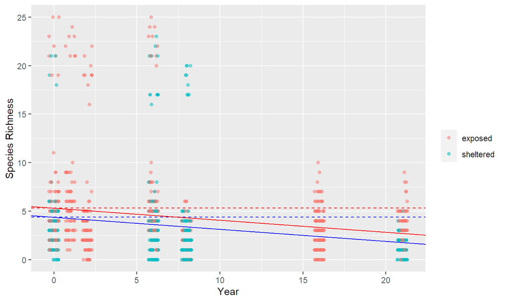

```r
ANCOVAplot
```

## Interactions

But what if we think the effect of year might be different at the exposed vs. sheltered sites? For this we’ll need to add an interaction term to the linear equation.

\[ \mu = \beta_0 + \beta_1x + (\beta_2 \times year) + (\beta_3x \times year) \]

You can think of \(\beta_3\) like a special slope modifier that gets turned on only for the second group.

## Fit the model

```r
wizard.ANCOVA <-
  lm(richness ~ exposure * year,  # as easy as that!
     data = wizard2)
summary(wizard.ANCOVA)  # Which values match which parameters?
```

```
##
## Call:
## lm(formula = richness ~ exposure * year, data = wizard2)
##
## Residuals:
##     Min      1Q  Median      3Q     Max
## -5.1191 -2.3886 -0.9792  0.7392 20.4118
##
## Coefficients:
##                        Estimate Std. Error t value Pr(>|t|)
## (Intercept)             5.38457    0.25526  21.094  < 2e-16 ***
## exposuresheltered      -1.12642    0.42099  -2.676  0.00758 **
## year                   -0.13273    0.02433  -5.455 6.14e-08 ***
## exposuresheltered:year  0.02421    0.04065   0.596  0.55159
## ---
## Signif. codes:  0 '***' 0.001 '**' 0.01 '*' 0.05 '.' 0.1 ' ' 1
##
## Residual standard error: 4.462 on 1030 degrees of freedom
## Multiple R-squared:  0.04745,    Adjusted R-squared:  0.04468
## F-statistic:  17.1 on 3 and 1030 DF,  p-value: 7.606e-11
```

```r
beta.0 <- wizard.ANCOVA$coefficients[1]
beta.1 <- wizard.ANCOVA$coefficients[2]
beta.2 <- wizard.ANCOVA$coefficients[3]
beta.3 <- wizard.ANCOVA$coefficients[4]
```

## And plot

```r
ANCOVAplot <-
  ggplot(wizard2) +
  geom_jitter(aes(x = year, y = richness, colour = exposure),
              width = 0.3, height = 0, alpha = 0.5) +
  labs(x = "Year", y = "Species Richness") +
  geom_hline(aes(yintercept = beta.0), colour = "red",
             linetype = "dashed") +
  geom_hline(aes(yintercept = beta.0 + beta.1), colour = "blue",
             linetype = "dashed") +
  geom_abline(aes(intercept = beta.0, slope = beta.2), colour = "red") +
  geom_abline(aes(intercept = beta.0 + beta.1, slope = beta.2
                  + beta.3), # this is the only difference!
              colour = "blue") +
  scale_colour_discrete(name = "")
```

## View the plot

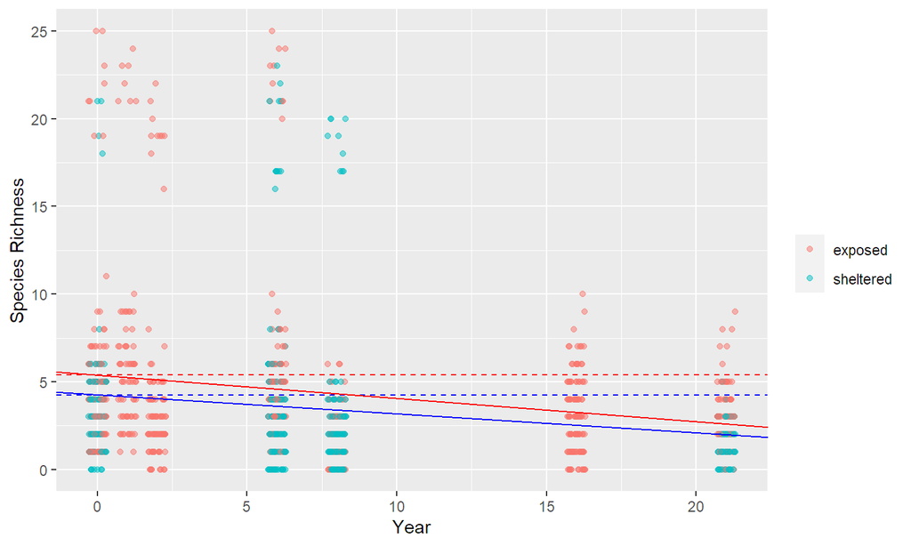

```r
ANCOVAplot
```

Why doesn’t this look that different?

## Diagnose the model

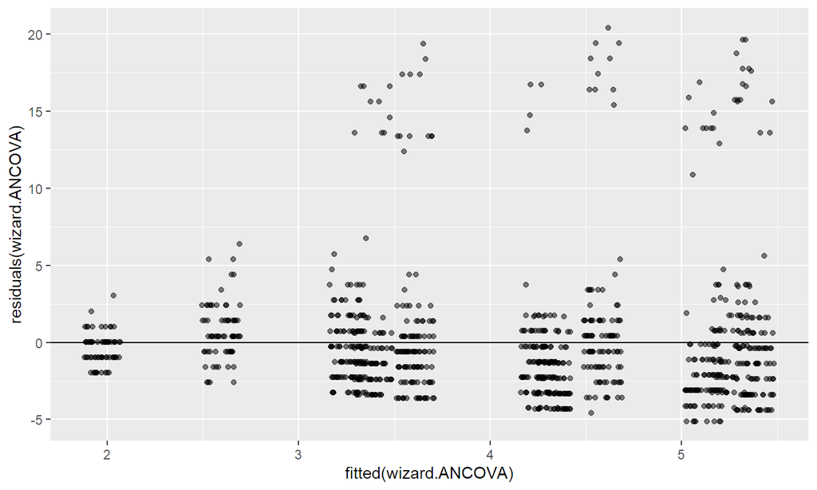

```r
ggplot() +
  geom_jitter(aes(x = fitted(wizard.ANCOVA), y = residuals(wizard.ANCOVA)),
              width = 0.1, height = 0, alpha = 0.5) +
  geom_hline(aes(yintercept = 0))
```

## What do the model predictions look like?

```r
dummydata <- expand.grid(exposure = c("exposed", "sheltered"),
                         year = c(0:21))

dummypredict <- predict(wizard.ANCOVA, newdata = dummydata, se.fit = TRUE)

dummydata$fitted <- dummypredict$fit
dummydata$lower95 <- with(dummypredict, fit - 1.96 * se.fit)
dummydata$upper95 <- with(dummypredict, fit + 1.96 * se.fit)
```

```r
ANCOVAplot <-
  ggplot(wizard2) +
  geom_ribbon(data = dummydata, aes(x = year, ymin = lower95, ymax = upper95,
                                    fill = exposure), alpha = 0.3) +
  geom_jitter(aes(x = year, y = richness, colour = exposure),
              width = 0.3, height = 0, alpha = 0.5) +
  labs(x = "Year", y = "Species Richness") +
  geom_line(data = dummydata, aes(x = year, y = fitted,
                                  colour = exposure)) +
  scale_colour_viridis_d(name = "") +
  scale_fill_viridis_d(name = "") +
  theme_classic()
```

## View the plot

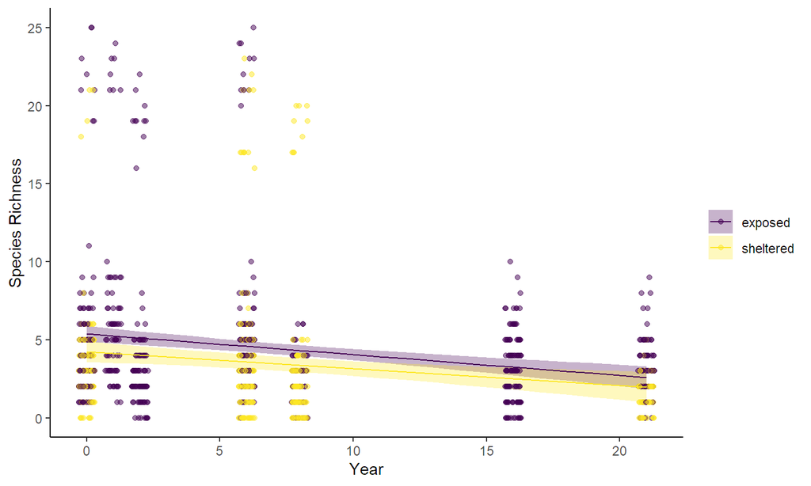

```r
ANCOVAplot
```

## Transformation

We could try solving our residuals issue by doing a log(\(x\) + 1) transformation on the response variable.

```r
wizard.ANCOVA <-
  lm(log(richness + 1) ~ exposure * year,
     data = wizard2)
```

## Plot residuals again

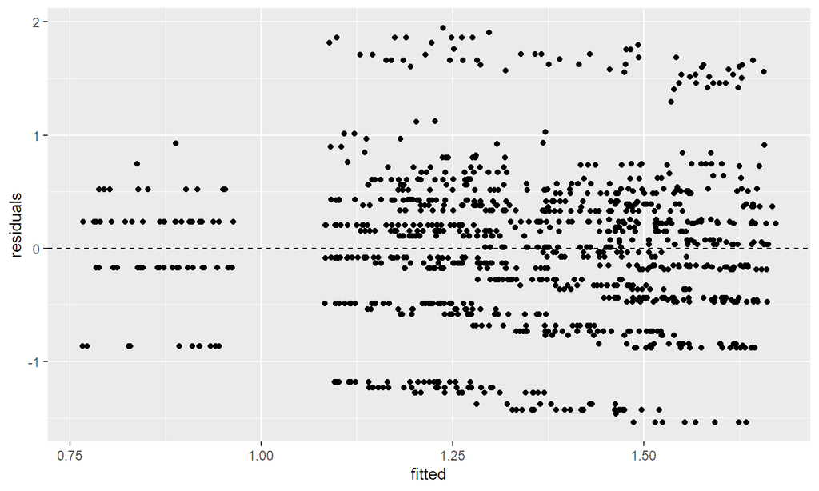

```r
residuals <- resid(wizard.ANCOVA)
fitted <- fitted(wizard.ANCOVA)
ggplot() +
  geom_jitter(aes(x = fitted, y = residuals), width = 0.1, height = 0) +
  geom_hline(aes(yintercept = 0), linetype = "dashed")
```

That looks way better!

## What does that do to our model results?

```r
summary(wizard.ANCOVA)
```

```
##
## Call:
## lm(formula = log(richness + 1) ~ exposure * year, data = wizard2)
##
## Residuals:
##      Min       1Q   Median       3Q      Max
## -1.53728 -0.43867  0.03493  0.37950  1.94811
##
## Coefficients:
##                         Estimate Std. Error t value Pr(>|t|)
## (Intercept)             1.574504   0.039294  40.069  < 2e-16 ***
## exposuresheltered      -0.198493   0.064805  -3.063  0.00225 **
## year                   -0.018610   0.003746  -4.968  7.9e-07 ***
## exposuresheltered:year -0.005735   0.006258  -0.916  0.35967
## ---
## Signif. codes:  0 '***' 0.001 '**' 0.01 '*' 0.05 '.' 0.1 ' ' 1
##
## Residual standard error: 0.6868 on 1030 degrees of freedom
## Multiple R-squared:  0.07006,    Adjusted R-squared:  0.06735
## F-statistic: 25.87 on 3 and 1030 DF,  p-value: 3.905e-16
```

## What do our model predictions look like now?

```r
dummydata <- expand.grid(exposure = c("exposed", "sheltered"),
                         year = c(0:21))

dummypredict <- predict(wizard.ANCOVA, newdata = dummydata, se.fit = TRUE)

dummydata$fitted <- exp(dummypredict$fit) - 1
dummydata$lower95 <- exp(with(dummypredict, fit - 1.96 * se.fit)) - 1
dummydata$upper95 <- exp(with(dummypredict, fit + 1.96 * se.fit)) - 1
```

```r
ANCOVAplot <-
  ggplot(wizard2) +
  geom_ribbon(data = dummydata, aes(x = year, ymin = lower95, ymax = upper95,
                                    fill = exposure), alpha = 0.3) +
  geom_jitter(aes(x = year, y = richness, colour = exposure),
              width = 0.3, height = 0, alpha = 0.5) +
  labs(x = "Year", y = "Species Richness") +
  geom_line(data = dummydata, aes(x = year, y = fitted,
                                  colour = exposure)) +
  scale_colour_viridis_d(name = "") +
  scale_fill_viridis_d(name = "") +
  theme_classic()
```

## View the plot

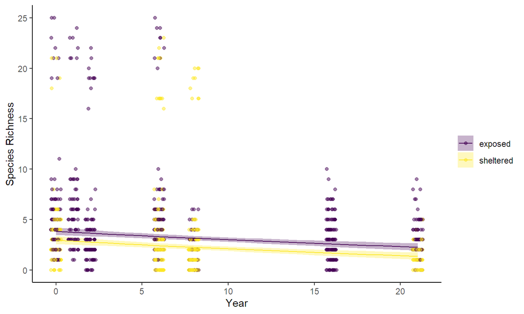

```r
ANCOVAplot
```